# Introducción a la Ciencia de Datos en R - CPS

Ramiro Oliverio Fernández, Hernán Escudero

2019-09-20

### Referencias

Este curso está basado en: * [Ciencia de Datos para Gente Sociable](https://bitsandbricks.github.io/ciencia_de_datos_gente_sociable/) de Antonio Vazquez Brust * [Introducción a Data Science](https://github.com/DiegoKoz/intro_ds) de Diego Kozlowski y Natsumi Shokida * Clases de Santiago Banchero y Juan Manuel Fernández en la Maestría de Data Mining de la UBA. https://dmuba.github.io/

## Introducción breve a Data Science

- Mayor volumen de datos
- Disponibilidad de accesos (APIs)
- Datos abiertos
- Múltiples y diversas aplicaciones de la Ciencia de Datos

El término está adquiriendo cada vez mayor popularidad:

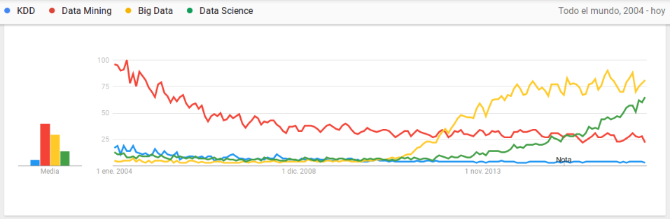

También ciencia de datos se intercambia con otros términos: data mining/kdd/data analysis/BI/etc.

Se nutre y está relacionado con diferentes campos/temáticas:

- Estadística
- Machine Learning / Aprendizaje Automático
- Data Warehouse
- BDD
- Algoritmos
- Reconocimiento de patrones
- Visualizaciones
- HPC (High Performance Computing)

Relacionado con Knowledge Discovery in Databases, concepto para describir el proceso de cómo extraer conocimiento basado y potenciado por los datos.

Proceso **interactivo e iterativo**:

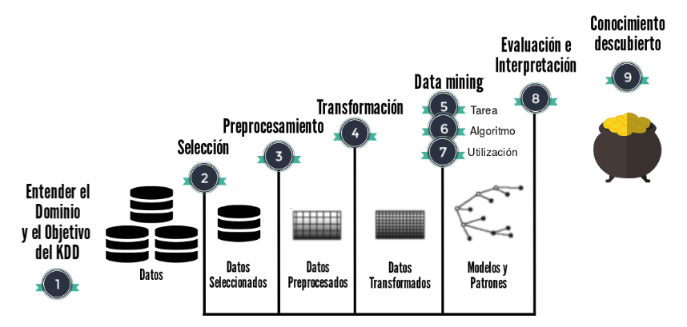

Algunas aplicaciones del data science:

- Reconocimiento y análisis de imagenes (médicas por ej.)
- Detección de fraude
- Sistemas de recomendación
- Reconocimiento de voz
- Web Mining

## Intro a R

- Lenguaje de programación para análisis de datos
- Software libre y gratuito
- Comunidad dinámica y abierta. Específicamente en Buenos Aires: [R-Ladies Buenos Aires](https://www.meetup.com/es-ES/rladies-buenos-aires/) y [RenBaires](https://www.meetup.com/es-ES/renbaires/)
- Principalmente motorizado por los aportes de sus usuarios (vía paquetes y [stackoverflow](https://stackoverflow.com/))

Se puede descargar [aquí](https://cran.rstudio.com/)

El entorno de desarrollo integrado (“IDE”, por sus siglas en inglés) más popular es RStudio. Se puede descargar [aquí](https://www.rstudio.com/products/rstudio/download/)

Así se ve el entorno:

[figure not shown]

## Primeras operaciones en R

R es un lenguaje de programación **orientado a objetos**, los cuales son fundamentales para el mismo. Todo lo que se guarda en R es un objeto con un nombre específico que no permite espacios. Hay diferentes tipos de objetos: números, listas, funciones, gráficos, tablas y muchos más que ya iremos viendo. Los objetos se almacenan en el ambiente (environment).

El operador **`<-`** se utiliza para definir objeto. Es un operador unidireccional, por lo cual **A la izquierda** del **`<-`** debe ubicarse el nombre que tomará el elemento a crear. **Del lado derecho** debe ir la definición del mismo. Al definir un objeto, su contenido queda guardado en el ambiente para poder ser usado de forma posterior. También se puede utilizar `=`.

Para ejecutar cada línea de código, debemos ejecutarla presionando `Ctrl` + `Enter`. Seleccionando varías líneas de código y utilizando el mismo comando (`Ctrl` + `Enter`) se irán ejecutando una por una.

```r
ejemplo1 <- 1
ejemplo1
```

```
## [1] 1
```

Una vez que tenemos el objeto `ejemplo1` creado, podemos hacer operaciones sobre el mismo ya que está guardado.

```r
ejemplo1*3
```

```
## [1] 3
```

Con esta última operación, `ejemplo 1` no cambia su valor a 3, solamente cambia para el output de esa línea de código. Para guardar el cambio, hay que asignar ese output a un objeto (sea `ejemplo1` o algún otro)

### Diferentes tipos de operadores

#### Operadores lógicos

- Mayor a: $>$ o menor a: $<$
- Mayor o igual a: $>=$ o menor o igual a: $<=$
- Igual a: $==$
- Distinto a: $!=$ (distinto a-)

```r
# Redefinimos los valores A y B
A <- 10
B <- 20
# Realizamos comparaciones lógicas
A >  B
```

```
## [1] FALSE
```

```r
A >= B
```

```
## [1] FALSE
```

```r
A <  B
```

```
## [1] TRUE
```

```r
A <= B
```

```
## [1] TRUE
```

```r
A == B
```

```
## [1] FALSE
```

```r
A != B
```

```
## [1] TRUE
```

```r
C <- A != B
C
```

```
## [1] TRUE
```

#### Operadores aritméticos:

```r
#suma
ejsuma <- 3+3
ejsuma
```

```
## [1] 6
```

```r
#cociente
ejcociente <- 7/2.5
ejcociente
```

```
## [1] 2.8
```

```r
#potencia
ejpotencia <- 5^2.5
ejpotencia
```

```
## [1] 55.9017
```

### Tipos de objetos:

Hay diferentes tipos de objetos en R, vamos a ver algunos de ellos:

#### Valores

Los valores (y vectores que los contienen) pueden ser de distintas *clases*, las principales son las siguientes:

- character: `"bew"`, `frase estándar`
- numeric (real or decimal): `3.5`
- integer: `3`
- logical: booleanos (`TRUE`, `FALSE`)

Con la función `class()` podemos consultar la clase del objeto. **Numeric**

```r
numero <-  1
class(numero)
```

```
## [1] "numeric"
```

**Character**

```r
palabra <-  "ejemplo"
class(palabra)
```

```
## [1] "character"
```

**Factor**

```r
A <- factor("Nivel 1 de un factor")
class(A)
```

```
## [1] "factor"
```

```r
levels(A)
```

```
## [1] "Nivel 1 de un factor"
```

La diferencia entre un *character* y un *factor* es que el último tiene solo algunos valores permitidos (funcionan como categorías predefinidas, los podemos consultar con la funcion `levels()`), con un orden interno que se mantiene a la hora de graficar por ejemplo.

#### Vectores

Para generar un vector utilizamos el comando `c()`.

```r
ejvector <- c(1, 3, 4)
ejvector
```

```
## [1] 1 3 4
```

Podemos realizar diferentes operaciones sobre ese vector

```r
ejvector * 2
```

```
## [1] 2 6 8
```

Utilizando los dos puntos `:` indicamos a R que vaya de un valor al otro, sirve para generar un vector por ejemplo.

```r
ejvector2 <- c(1:5)
```

Podemos crear un vector que contenga diferentes `strings`

```r
utiles <- c("Lapicera", "Lápiz", "Goma de borrar")
utiles
```

```
## [1] "Lapicera"       "Lápiz"          "Goma de borrar"
```

Si intentamos crear vector que contenga diferentes tipos de valores, R va a forzar a que sean de un mismo tipo

```r
a <- c(1, "asd", 3)
a
```

```
## [1] "1"   "asd" "3"
```

```r
class(a[1])
```

```
## [1] "character"
```

Para acceder a algún elemento del vector, podemos buscarlo por su número de orden que funciona como su número de índice, entre `[ ]`. En R, los índices comienzan con 1 (a diferencia de la mayoría de los lenguajes de programación, donde empiezan con el 0)

```r
utiles[3]
```

```
## [1] "Goma de borrar"
```

Este valor lo podemos almacenar en un objeto nuevo, y se va a almacenar solamente este valor

```r
ultimoutil <- utiles[3]
ultimoutil
```

```
## [1] "Goma de borrar"
```

También podemos usar la posición en ese vector para reemplazar el valor

```r
utiles[3] <- "sacapuntas"
utiles
```

```
## [1] "Lapicera"   "Lápiz"      "sacapuntas"
```

Hay varias funciones que nos permiten generar vectores. Por ejemplo, `rep()` genera repeticiones con ciertos parámetros que son `èach` para indicar el N de repeticiones y `length` para indicar el largo del vector. Sin `length`, cada valor del vector se repite la cantidad N de veces indicada 1 sola vez para cada valor. También funciona para valores numéricos.

```r
colores <- rep(c("verde", "rojo"), each=4, length=18)
colores
```

```
##  [1] "verde" "verde" "verde" "verde" "rojo"  "rojo"  "rojo"  "rojo"
##  [9] "verde" "verde" "verde" "verde" "rojo"  "rojo"  "rojo"  "rojo"
## [17] "verde" "verde"
```

Por otra parte, `seq()` es exclusivamente para generar una secuencia de valores numéricos con un cierto patrón. El argumento opcional `"by"` indica de cuánto son los saltos. Sin este argumento, pasa de 1 a 1.

```r
seq(1,10, by=3)
```

```
## [1]  1  4  7 10
```

### Data Frames

Un Data Frame es una tabla de datos, donde las columnas representan variables y las filas observaciones/registros

Seguramente resulte central en nuestro proceso de trabajo, ya que muchos de los datos que vamos a lidiar son tabulares y permiten diferentes operaciones, modelos y funciones muy útiles y diversas.

Al igual que un vector se puede entender como una concatenación de valores, se puede entender a un dataframe como una combinación de N vectores del mismo tamaño. Por ejemplo, tomamos como ejemplo los [Garajes de CABA](https://data.buenosaires.gob.ar/dataset/garajes-comerciales)

```r
SMP  <- c("047-106-028","033-044-012", "033-056C-023A", "033-012-031", "033-023-032")
CALLENOMBRE  <-  c("ARENAL, CONCEPCION","BONPLAND","CORDOBA",
                   "RAMIREZ DE VELAZCO, JUAN","BONPLAND")
CALLEALTURA  <-  c(4519, 1147, 5640, 1418, 966)
garajes <- data.frame(SMP, CALLENOMBRE, CALLEALTURA)
garajes
```

```
##             SMP              CALLENOMBRE CALLEALTURA
## 1   047-106-028       ARENAL, CONCEPCION        4519
## 2   033-044-012                 BONPLAND        1147
## 3 033-056C-023A                  CORDOBA        5640
## 4   033-012-031 RAMIREZ DE VELAZCO, JUAN        1418
## 5   033-023-032                 BONPLAND         966
```

Al igual que en un **vector** se accede a los elementos con `[ ]`, en un **dataframe** se accede a sus elementos de la forma **`[fila, columna]`**.

Otra opción es especificar la columna, mediante el operador `$`, y luego seleccionar el registro deseado.

```r
garajes$CALLEALTURA
```

```
## [1] 4519 1147 5640 1418  966
```

```r
garajes[4,2]
```

```
## [1] RAMIREZ DE VELAZCO, JUAN
## 4 Levels: ARENAL, CONCEPCION BONPLAND ... RAMIREZ DE VELAZCO, JUAN
```

```r
garajes$CALLEALTURA[4]
```

```
## [1] 1418
```

Si ya estamos llamando a una variable con el operador `$`, debemos sólo acceder a la posición del registro que estamos buscando.

Acceder a los **dataframes** mediante `[ ]` puede utilizarse para realizar filtros sobre la base, poniendo una condición para las filas. Por ejemplo, puedo utilizar los `[ ]` para conservar del **dataframe** `garajes` unicamente los registros de la calle Bonpland:

```r
garajes[garajes$CALLENOMBRE=="BONPLAND",]
```

```
##           SMP CALLENOMBRE CALLEALTURA
## 2 033-044-012    BONPLAND        1147
## 5 033-023-032    BONPLAND         966
```

Como vimos anteriormente, puedo usar este filtro y guardar la información en un nuevo objeto.

### Listas

Concatenan objetos de cualquier índole, sean dataframes, vectores, valores, otras listas y más.

```r
lista <- list(1, utiles, DF = garajes, CALLEALTURA, c(1,2,3))
lista
```

```
## [[1]]
## [1] 1
##
## [[2]]
## [1] "Lapicera"   "Lápiz"      "sacapuntas"
##
## $DF
##             SMP              CALLENOMBRE CALLEALTURA
## 1   047-106-028       ARENAL, CONCEPCION        4519
## 2   033-044-012                 BONPLAND        1147
## 3 033-056C-023A                  CORDOBA        5640
## 4   033-012-031 RAMIREZ DE VELAZCO, JUAN        1418
## 5   033-023-032                 BONPLAND         966
##
## [[4]]
## [1] 4519 1147 5640 1418  966
##
## [[5]]
## [1] 1 2 3
```

Para acceder un elemento de una lista, podemos utilizar los corchetes. podemos utilizar el operador **`$`**, que se puede usar a su vez de forma iterativa.

```r
lista
```

```
## [[1]]
## [1] 1
##
## [[2]]
## [1] "Lapicera"   "Lápiz"      "sacapuntas"
##
## $DF
##             SMP              CALLENOMBRE CALLEALTURA
## 1   047-106-028       ARENAL, CONCEPCION        4519
## 2   033-044-012                 BONPLAND        1147
## 3 033-056C-023A                  CORDOBA        5640
## 4   033-012-031 RAMIREZ DE VELAZCO, JUAN        1418
## 5   033-023-032                 BONPLAND         966
##
## [[4]]
## [1] 4519 1147 5640 1418  966
##
## [[5]]
## [1] 1 2 3
```

```r
lista$DF$CALLENOMBRE
```

```
## [1] ARENAL, CONCEPCION       BONPLAND
## [3] CORDOBA                  RAMIREZ DE VELAZCO, JUAN
## [5] BONPLAND
## 4 Levels: ARENAL, CONCEPCION BONPLAND ... RAMIREZ DE VELAZCO, JUAN
```

```r
lista[5]
```

```
## [[1]]
## [1] 1 2 3
```

### Matrices

Las matrices son estructuras bidimensionales (como los dataframe), donde los valores son del mismo tipo (como en los vectores). Son útiles ya que, al igual que con las listas, muchas funciones o modelos de R devuelven matrices o las toman como argumento. Se generaon con `matrix()`, con los argumentos de la data a pasarle, la cantidad de filas y columnas y el parámetro `byrow` que indica si la matriz se completa por las filas o por las columnas (por default es `TRUE`, es decir se llena por filas).

```r
matrix (1:8, nrow=2, ncol=4, byrow = TRUE)
```

```
##      [,1] [,2] [,3] [,4]
## [1,]    1    2    3    4
## [2,]    5    6    7    8
```

### Uso de ciertos caracteres en R

- R distingue entre minúsculas y mayúsculas
- El numeral `#` se utiliza para hacer comentarios, todo lo que vaya después del mismo no es “leído” por R. Se debe utilizar por línea que se quiera comentar.
- Como vimos anteriormente, los corchetes se utilizan para acceder a los elementos.
- También vimos que `$` es una forma de acceso, en los dataframes para acceder a las columnas pero tiene otros casos de uso también.
- Los paréntesis `()` engloban los parámetros de la función a la que estamos llamando
- Las comas `,` separan parámetros de una función.

### Instalar librerías

Hasta ahora, hemos trabajado con lo que se llama `R Base`, es decir las funciones que R contiene como base, pero gran parte de su riqueza está en las librerías que crean sus usuarios.

Se instalan con el comando `install.packages()`, cuyo parámetro es el nombre de la librería entre paréntesis. También se puede pasar un vector de nombres de librerías para instalar varias a la vez.

Cada vez que se inicia una sesión en R, se debe llamar a las librerías que deseamos usar con el parámetro `library()`

Vamos a instalar algunas librerías que utilizaremos:

```r
#install.packages(c("tidyverse", "data.table", "openxlsx", "readxl", "xlsx", "ggthemes"),repos = "http://cran.us.r-project.org")
```

### Lectura/escrituras de archivos – CSV/TXT

Vamos a empezar viendo cómo levantar archivos en los formatos de datos tabulares más clásicos: csv, txt y excel.

Hay muchas funciones para levantar csv o txt, sobre todo cambian: el delimitador, el encabezado y el separador decimal.

Vamos a utilizar la función `read.csv` (pero podría ser `read.table`, `fread`, `read.delim`, en general cambian sus parámetros default, hay algunas más óptimas que otras, aunque por ejemplo `fread()` no es de R Base). Le estamos pasando como parámetro de ubicación una URL (generada por el portal de datos de CABA), pero puede ser la ubicación de un archivo en la pc local (línea de código comentada)

```r
radares <- read.csv("http://cdn.buenosaires.gob.ar/datosabiertos/datasets/flujo-vehicular-por-radares-ausa/flujo-vehicular-por-radares-2019.csv", header=TRUE, sep=',', dec='.')
head(radares)
```

```
##   X      fecha hora autopista_nombre     disp_nombre disp_ubicacion
## 1 0 2019-01-01    0    AU 4  Lugones   RD165 Dorrego           4.74
## 2 1 2019-01-01    0    AU 4  Lugones    RD166 Ombues           5.50
## 3 2 2019-01-01    0    AU 4  Lugones RD168 Juramento           7.20
## 4 3 2019-01-01    0    AU 4  Lugones    RD169 Monroe           8.11
## 5 4 2019-01-01    0    AU 4  Lugones   RD170 Udaondo           8.68
## 6 5 2019-01-01    0    AU 4  Lugones      RD171 Esma           9.90
##   seccion_sentido       lat      long cantidad
## 1               A -34.56336 -58.41529      618
## 2               A -34.56044 -58.41908      797
## 3               A -34.54977 -58.43602       66
## 4               A -34.54629 -58.44224      857
## 5               A -34.54293 -58.44901      861
## 6               A -34.53767 -58.45967      834
```

```r
#radares <- read.csv("C:/Users/rama_/Desktop/Ramiro/Transito radares ausa/flujo-vehicular-por-radares-2019.csv", header=TRUE, sep=',', dec='.')
# si esta en mi directorio de trabajo, directamente:
#radares <- read.csv("flujo-vehicular-por-radares-2019.csv", header=TRUE, sep=',', dec='.')
#probamos levantar un archivo .txt
indicadoresmoc <- read.csv("http://cdn.buenosaires.gob.ar/datosabiertos/datasets/mapa-de-oportunidades-comerciales-moc/COMERCIOS.TXT", sep='\t')
```

Una vez que tenemos cargado un dataframe (`radares` en este caso), podemos aplicar varias funciones para explorarlo.

Podemos “imprimir” (deriva de la función `print`) sus primeros o sus últimos registros

```r
head(radares)
```

```
##   X      fecha hora autopista_nombre     disp_nombre disp_ubicacion
## 1 0 2019-01-01    0    AU 4  Lugones   RD165 Dorrego           4.74
## 2 1 2019-01-01    0    AU 4  Lugones    RD166 Ombues           5.50
## 3 2 2019-01-01    0    AU 4  Lugones RD168 Juramento           7.20
## 4 3 2019-01-01    0    AU 4  Lugones    RD169 Monroe           8.11
## 5 4 2019-01-01    0    AU 4  Lugones   RD170 Udaondo           8.68
## 6 5 2019-01-01    0    AU 4  Lugones      RD171 Esma           9.90
##   seccion_sentido       lat      long cantidad
## 1               A -34.56336 -58.41529      618
## 2               A -34.56044 -58.41908      797
## 3               A -34.54977 -58.43602       66
## 4               A -34.54629 -58.44224      857
## 5               A -34.54293 -58.44901      861
## 6               A -34.53767 -58.45967      834
```

```r
tail(radares)
```

```
##             X      fecha hora autopista_nombre        disp_nombre
## 141050 141049 2019-08-30   23    AU Dellepiane       RD105 Homero
## 141051 141050 2019-08-30   23    AU Dellepiane        RD106 Zinny
## 141052 141051 2019-08-30   23    AU Dellepiane        RD106 Zinny
## 141053 141052 2019-08-30   23    AU Dellepiane RD108 Ramal a 27f.
## 141054 141053 2019-08-30   23    AU Dellepiane    RD110 Fernandez
## 141055 141054 2019-08-30   23    AU Dellepiane      RD111 Ramal 9
##        disp_ubicacion seccion_sentido       lat      long cantidad
## 141050           3.26               B -34.66044 -58.47124     1961
## 141051           3.88               A -34.65465 -58.46901     1417
## 141052           3.88               B -34.65465 -58.46901     1844
## 141053           4.30               A -34.65369 -58.46812      460
## 141054           4.30               B -34.65288 -58.46818      130
## 141055           0.18               B -34.65061 -58.46677      202
```

Podemos ver un resumen de sus variables

```r
summary(radares)
```

```
##        X                 fecha             hora
##  Min.   :     0   2019-01-05:   768   Min.   : 0.00
##  1st Qu.: 35264   2019-01-06:   768   1st Qu.: 5.00
##  Median : 70527   2019-01-20:   768   Median :11.00
##  Mean   : 70527   2019-01-24:   768   Mean   :11.42
##  3rd Qu.:105791   2019-01-07:   763   3rd Qu.:17.00
##  Max.   :141054   2019-01-18:   763   Max.   :23.00
##                   (Other)   :136457
##           autopista_nombre             disp_nombre    disp_ubicacion
##  AU 4  Lugones    :29363   RD134 Ituzaingo   : 9986   Min.   :0.160
##  AU 5 Cantilo     :16514   RD105 Homero      : 9912   1st Qu.:1.160
##  AU 9 de Julio Sur:52444   RD106 Zinny       : 8794   Median :3.260
##  AU Dellepiane    :42734   RD100 Montiel     : 8492   Mean   :3.896
##                            RD131 Brandsen B  : 5013   3rd Qu.:7.200
##                            RD108 Ramal a 27f.: 4990   Max.   :9.900
##                            (Other)           :93868
##  seccion_sentido      lat              long           cantidad
##  A:72509         Min.   :-34.68   Min.   :-58.48   Min.   :    0
##  B:68546         1st Qu.:-34.65   1st Qu.:-58.47   1st Qu.: 1036
##                  Median :-34.64   Median :-58.44   Median : 2599
##                  Mean   :-34.62   Mean   :-58.43   Mean   : 2856
##                  3rd Qu.:-34.55   3rd Qu.:-58.38   3rd Qu.: 4045
##                  Max.   :-34.54   Max.   :-58.37   Max.   :10397
##
```

Los nombres de sus columnas (también se puede usar `names`, `colnames` aplica para matrices también, aunque names aplica para vectores)

```r
colnames(radares)
```

```
##  [1] "X"                "fecha"            "hora"
##  [4] "autopista_nombre" "disp_nombre"      "disp_ubicacion"
##  [7] "seccion_sentido"  "lat"              "long"
## [10] "cantidad"
```

Cantidad de filas y cantidad de columnas. `length` también es muy utilizado, ya que aplica para otros tipos de objetos.

```r
nrow(radares)
```

```
## [1] 141055
```

```r
ncol(radares)
```

```
## [1] 10
```

```r
length(radares)
```

```
## [1] 10
```

La función `unique()` nos devuelve un vector con valores únicos desduplicados.

```r
unique(radares$autopista_nombre)
```

```
## [1] AU 4  Lugones     AU 5 Cantilo      AU 9 de Julio Sur AU Dellepiane
## Levels: AU 4  Lugones AU 5 Cantilo AU 9 de Julio Sur AU Dellepiane
```

La función `table()` devuelve una tabla de frecuencias absolutas con la cantidad de registros por categoría para la variable.

```r
tabla <- table(radares$autopista_nombre)
tabla
```

```
##
##     AU 4  Lugones      AU 5 Cantilo AU 9 de Julio Sur     AU Dellepiane
##             29363             16514             52444             42734
```

Con `prop.table` vemos la tabla de frecuencias relativa, la usamos con el objeto `tabla` creado más arriba

```r
prop.table(tabla)
```

```
##
##     AU 4  Lugones      AU 5 Cantilo AU 9 de Julio Sur     AU Dellepiane
##         0.2081670         0.1170749         0.3717982         0.3029598
```

Puedo hacer una tabla bi-variada también

```r
table(radares$autopista_nombre, radares$seccion_sentido)
```

```
##
##                         A     B
##   AU 4  Lugones     29363     0
##   AU 5 Cantilo          0 16514
##   AU 9 de Julio Sur 23990 28454
##   AU Dellepiane     19156 23578
```

Obtener la media

```r
mean(radares$cantidad, na.rm = TRUE)
```

```
## [1] 2856.372
```

Sumar una columna numérica

```r
sum(radares$cantidad)
```

```
## [1] 402905517
```

Subsetear el dataframe filtrandolo!

```r
radareslugonesydelle <- subset(radares, (radares$autopista_nombre=='AU 4  Lugones')|(radares$autopista_nombre=='AU Dellepiane'))
head(radareslugonesydelle)
```

```
##   X      fecha hora autopista_nombre     disp_nombre disp_ubicacion
## 1 0 2019-01-01    0    AU 4  Lugones   RD165 Dorrego           4.74
## 2 1 2019-01-01    0    AU 4  Lugones    RD166 Ombues           5.50
## 3 2 2019-01-01    0    AU 4  Lugones RD168 Juramento           7.20
## 4 3 2019-01-01    0    AU 4  Lugones    RD169 Monroe           8.11
## 5 4 2019-01-01    0    AU 4  Lugones   RD170 Udaondo           8.68
## 6 5 2019-01-01    0    AU 4  Lugones      RD171 Esma           9.90
##   seccion_sentido       lat      long cantidad
## 1               A -34.56336 -58.41529      618
## 2               A -34.56044 -58.41908      797
## 3               A -34.54977 -58.43602       66
## 4               A -34.54629 -58.44224      857
## 5               A -34.54293 -58.44901      861
## 6               A -34.53767 -58.45967      834
```

Puedo guardar este objeto en mi PC local con `write.csv()` con los parámetros: objeto a guardar, nombre (y ubicación, aquí por default se me guardará en mi directorio predeterminado) y la última opción evita que R guarde el índice de las filas

```r
write.csv(radareslugonesydelle, "radares-lugones-y-dellepiane.csv", row.names = FALSE)
```

Para remover un objeto del ambiente, usamos

```r
rm(radares)
```

Para remover todos los objeto del ambiente, usamos

```r
rm(list=ls())
```

### Otras funciones

Vamos a ver dos funciones básicas que seguramente utilicemos. `paste()` para concatener serie de caracteres (u objetos que los almacenen) y `print()` que imprime lo que le indiquemos.

```r
paste("Armamos", "una", "frase", sep= " ")
```

```
## [1] "Armamos una frase"
```

```r
frasearmada <- paste("Armamos", "una", "frase", sep= " ")
print (frasearmada)
```

```
## [1] "Armamos una frase"
```

### Lectura/escrituras de archivos – Excel

Para leer y escribir archivos en excel, también hay varias funciones. A diferencia de csv y txt (son formatos libres y abiertos) pueden ser tanto la librería `openxlsx`, `readxl` o `xlsx`. Ahora levantaremos un archivo con formato `.xlsx`, que es el formato abierto basado en XML (similar a HTML) que se usa en muchos archivos excel. También los archivos excel pueden estar en `.xls`, que es formato propietario de MS Office (Excel).

```r
#install.packages("openxlsx")
library("openxlsx")
importaciones_bienes_cap_prod <- read.xlsx("http://estadisticas.produccion.gob.ar/app/documentos/bsk-prod-clasificacion.xlsx")
#para grabar, paso los parametros de: nombre de objeto, nombre del archivo qeu voy a guardar (y su ruta en nuestra PC), y el parámetro row.names que ya vimos
write.xlsx(importaciones_bienes_cap_prod, "importaciones.xlsx", row.names=FALSE)
```

```
## Note: zip::zip() is deprecated, please use zip::zipr() instead
```

### Formatos

Algunas aclaraciones:

1. El directorio queda referido a un lugar específico en nuestra computadora local. Si compartimos el script con otro, si cambiamos de pc, si cambiamos la carpeta de lugar u otras operaciones que afecten a esa ruta, las operaciones que impliquen la misma se rompe.
2. El ambiente muestra resultados de diferentes trabajos, no indica qué script lo generó. Esto se puede evitar utilizado proyectos (archivos .Rproj), que generan un ambiente específico para cada proyecto e implica toda una carpeta de trabajo

Rstudio tiene una herramienta muy útil de trabajo que son los **proyectos**. Estos permiten mantener un ambiente de trabajo delimitado por cada uno de nuestros trabajos.

### Tipos de archivos de R

- **Script**: Es un archivo de texto plano, donde podemos poner el código que utilizamos para preservarlo
- **Rnotebook**: También sirve para guardar el código, pero a diferencia de los scripts, se puede compilar (y exportar en diferentes formatos), e intercalar código con resultados (esto es un rnotebook)
- **Rproject**: Es un archivo que define la metadata del proyecto y nos permite tener ambientes “independientes”
- **RDS y Rdata**: Dos formatos de archivos propios de R para guardar datos. Sirven para cargar data rápidamente.

### Lecturas recomendadas

- [Tidy Data - Hadley Wickham](https://vita.had.co.nz/papers/tidy-data.pdf) Uno de los principales impulsores de R, en este paper explica lo que se considera “Tidy Data”
- [Data Science Livebook - Pablo Casas](https://livebook.datascienceheroes.com/)
- [Cookbook for R](http://www.cookbook-r.com/) Muchas soluciones a algunos problemas básicos de R
- Cheatsheets! Por ejemplo, [Data Science Cheatsheet](https://github.com/ml874/Data-Science-Cheatsheet) o [R Cheatsheet](https://www.rstudio.com/resources/cheatsheets/)

### Algunos ejercicios

- Probar armar diversos vectores usando: valores numéricos, de texto (“character”) y probar transformaciones de los mismos.
- Con dichos vectores, formar un dataframe.
- Probar levantar archivos excel, csv y txt.
- Probar las funciones que vimos en la clase.
- Grabar archivos en excel y csv.